# Predicting Price Paid to Coffee Growers

Bryce Dubayah

[figure not shown]

Globally, coffee is grown in over fifty countries lying between latitudes 25 degrees north and 30 degrees south. 70% of the world's coffee is produced by smallholder farmers, with half living in poverty. These growers rely on the price of coffee (as set by the commodity futures market) being high enough to cover production costs. Rather than the market price, however, the key factor that determines profitability is the amount paid directly to a coffee grower (the 'farmgate' price). While large, commercial farms can easily sell their coffee for market price, small growers or those in rural areas might not be able to, especially if they need to work with a large exporter. In this tutorial, we'll explore data on the coffee futures market and coffee production, examing if there are factors in addition to the market price that affect growers' earnings.

## The Data

The data used in this tutorial was sourced from the International Coffee Organization (ICO). The ICO works globally with importing and exporting countries to strengthen the coffee sector, with its member countries accounting for 98% of global coffee production and 67% of global coffee consumption. Through these partnerships, the ICO has extensive historical data on coffee supply, trade, and price. We will focus on the ICO datasets on domestic consumption in producing countries, exportable production (the difference of total production and domestic consumption), prices to growers (the average “farmgate” price paid to a grower), and monthly average coffee futures prices. With the exception of coffee futures prices, these data were reported yearly by country between 1990 and 2017. Units related to green coffee were reported in thousand 60kg bags, and prices were reported in U.S. cents.

### Market Prices

```python
import pandas as pd

url = 'http://www.ico.org/historical/1990%20onwards/Excel/3c%20-%20Indicator%20prices.xlsx'
col_names = ['date', 'composite', 'colombian_milds', 'other_milds', 'brazilian_naturals', 'robustas']
df = pd.read_excel(url, header=3, skipfooter=1, names=col_names).dropna(how='all')

df.head()
```

|  | date | composite | colombian_milds | other_milds | brazilian_naturals | robustas |
| --- | --- | --- | --- | --- | --- | --- |
| 1 | 1990 | 71.53 | 96.53 | 89.46 | 82.97 | 53.60 |
| 2 | January | 62.75 | 82.07 | 76.02 | 70.36 | 49.47 |
| 3 | February | 67.01 | 91.55 | 83.95 | 77.59 | 50.06 |
| 4 | March | 75.25 | 103.24 | 94.73 | 86.17 | 55.76 |
| 5 | April | 75.34 | 101.79 | 94.71 | 87.45 | 55.95 |

Immediately, we can see that the data is not tidy. While each row with a month name in the `date` column forms a unique observation, rows with a year in the `date` column are averages over that entire year. We need to transform the data so that each row has a month and year in the date column.

```python
from datetime import datetime
from matplotlib import dates

# build up new dataframe as a series of dicts
indicator_prices = []

# set base year
year = None

for index, row in df.iterrows():
    # some years were parsed as ints and some as strings
    if type(row['date']) == int or row['date'].isnumeric():
        year = str(row['date'])
    else:
        obs = {}
        month = row['date']
        date = datetime.strptime(month + year, '%B%Y')
        obs['date'] = dates.date2num(date)
        # add year as a separate column to easily align with other datasets
        obs['year'] = year
        for variety in col_names[1:]:
            obs[variety] = row[variety]
        indicator_prices.append(obs)

# convert series of dicts to dataframe
indicator_prices = pd.DataFrame(indicator_prices)

indicator_prices.head()
```

|  | date | year | composite | colombian_milds | other_milds | brazilian_naturals | robustas |
| --- | --- | --- | --- | --- | --- | --- | --- |
| 0 | 726468.0 | 1990 | 62.75 | 82.07 | 76.02 | 70.36 | 49.47 |
| 1 | 726499.0 | 1990 | 67.01 | 91.55 | 83.95 | 77.59 | 50.06 |
| 2 | 726527.0 | 1990 | 75.25 | 103.24 | 94.73 | 86.17 | 55.76 |
| 3 | 726558.0 | 1990 | 75.34 | 101.79 | 94.71 | 87.45 | 55.95 |
| 4 | 726588.0 | 1990 | 73.30 | 99.14 | 92.97 | 86.31 | 53.62 |

Let's look at the trend in coffee prices over time.

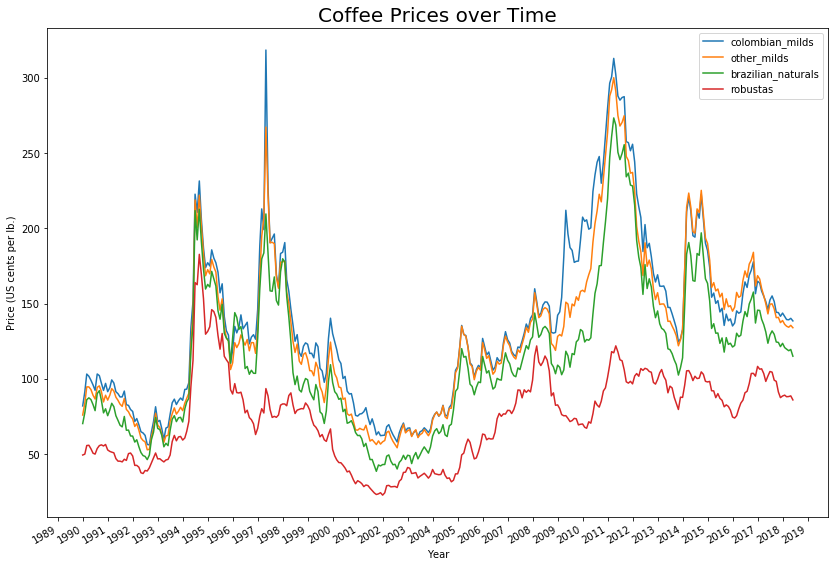

```python
%matplotlib inline
import matplotlib.pyplot as plt

fig, ax = plt.subplots()
fig.set_size_inches(14, 10)

# plot price data for every coffee variety
coffee_types = col_names[2:]
for coffee in coffee_types:
    line, = ax.plot(indicator_prices['date'], indicator_prices[coffee])
    line.set_label(coffee)

# format ticks
ax.xaxis.set_major_locator(dates.YearLocator())
ax.xaxis.set_major_formatter(dates.DateFormatter('%Y'))

# rotate and space labels
fig.autofmt_xdate()

ax.set_title('Coffee Prices over Time', fontsize=20)
ax.set_xlabel('Year')
ax.set_ylabel('Price (US cents per lb.)')
ax.legend()

plt.show()
```

The above graph shows how much coffee is sold for on international exchanges. There are many steps and associated costs between a grower in a coffee producing country and a commodity exchange (transport, export, import, etc. – see http://www.ncausa.org/about-coffee/10-steps-from-seed-to-cup for more info) that eat into the money a grower makes. So, how much do coffee growers make relative to the market price?

### Prices to growers

The ICO also collects data from their member countries on the average price per pound of green coffee paid to growers. This is what is referred to as a "farmgate" price: the actual amount of money that a grower earns. This would vary significantly between growers depending on the quality and type of coffee, and it's hard to imagine that the ICO obtained data from every grower, so we must treat these as rough estimates.

```python
url = 'http://www.ico.org/historical/1990%20onwards/Excel/3a%20-%20Prices%20paid%20to%20growers.xlsx'
df = pd.read_excel(url, header=3, skipfooter=1, na_values=[' ']).dropna(how='all')

# some of the year columns were strings and some were ints
df.columns = df.columns.astype(str)

df.head()
```

|  | Calendar years | 1990 | 1991 | 1992 | 1993 | 1994 | 1995 | 1996 | 1997 | 1998 | ... | 2008 | 2009 | 2010 | 2011 | 2012 | 2013 | 2014 | 2015 | 2016 | 2017 |
| --- | --- | --- | --- | --- | --- | --- | --- | --- | --- | --- | --- | --- | --- | --- | --- | --- | --- | --- | --- | --- | --- |
| 1 | Colombian Milds | NaN | NaN | NaN | NaN | NaN | NaN | NaN | NaN | NaN | ... | NaN | NaN | NaN | NaN | NaN | NaN | NaN | NaN | NaN | NaN |
| 2 | Colombia | 69.5230 | 67.1251 | 54.5709 | 50.1234 | 85.9942 | 99.6231 | 93.5556 | 133.1672 | 102.0805 | ... | 114.2209 | 138.9551 | 180.5484 | 239.6763 | 166.6921 | 113.9086 | 159.7125 | 119.4042 | 123.5571 | 125.7612 |
| 3 | Kenya | 60.5721 | 50.6778 | 28.9495 | 47.6419 | 152.6058 | 140.1651 | 110.0360 | 183.9967 | 179.8972 | ... | NaN | NaN | NaN | NaN | NaN | NaN | NaN | NaN | NaN | NaN |
| 4 | Tanzania | 40.8183 | 49.5039 | 49.1581 | 38.2833 | 62.1553 | 86.7599 | 62.5345 | 118.5236 | 90.7025 | ... | 63.3829 | NaN | NaN | NaN | NaN | NaN | NaN | NaN | NaN | NaN |
| 6 | Other Milds | NaN | NaN | NaN | NaN | NaN | NaN | NaN | NaN | NaN | ... | NaN | NaN | NaN | NaN | NaN | NaN | NaN | NaN | NaN | NaN |

5 rows × 29 columns

Compared to the first dataset, this one is transposed, with the rows as countries and the columns as years. Aditionally, there are some rows that signify the beginning of a group of producers. Let's first create a dict based on the `Calendar years` column that maps countries to producer groups:

```python
groups = ['Colombian Milds', 'Other Milds', 'Brazilian Naturals', 'Robustas']
curr_group = None

producer_groups = {}
for country_or_group in df['Calendar years']:
    if country_or_group in groups:
        curr_group = country_or_group
    else:
        producer_groups[country_or_group] = curr_group
```

Now, let's tidy the prices to growers dataset:

```python
df = df.set_index('Calendar years').dropna(how='all').T.reset_index()

df.head()
```

| Calendar years | index | Colombia | Kenya | Tanzania | Bolivia | Burundi | Cameroon | Congo, Dem. Rep. of | Costa Rica | Cuba | ... | Papua New Guinea | Philippines | Sierra Leone | Sri Lanka | Tanzania | Thailand | Togo | Trinidad & Tobago | Uganda | Vietnam |
| --- | --- | --- | --- | --- | --- | --- | --- | --- | --- | --- | --- | --- | --- | --- | --- | --- | --- | --- | --- | --- | --- |
| 0 | 1990 | 69.5230 | 60.5721 | 40.8183 | 51.7802 | 58.0195 | 32.2852 | NaN | 58.4893 | 171.4282 | ... | 26.5984 | 34.2253 | 26.1686 | 26.8959 | 17.0070 | 37.7181 | 29.2306 | 62.5882 | 7.5418 | 36.9183 |
| 1 | 1991 | 67.1251 | 50.6778 | 49.5039 | 52.4230 | 55.0206 | 28.2347 | NaN | 52.7258 | 171.4282 | ... | 29.4778 | 34.6061 | NaN | 25.2906 | 17.1071 | 18.3728 | 28.6435 | 62.5882 | 11.8428 | 30.7256 |
| 2 | 1992 | 54.5709 | 28.9495 | 49.1581 | 43.5276 | 59.2340 | 28.7593 | NaN | 49.9093 | 179.9996 | ... | 39.1005 | 42.4765 | NaN | 31.8496 | 14.8403 | 20.3048 | 29.8298 | 69.2941 | 8.9537 | 30.7070 |
| 3 | 1993 | 50.1234 | 47.6419 | 38.2833 | 27.3283 | 58.2708 | 23.2510 | NaN | 54.2666 | 188.5711 | ... | 54.8047 | 46.4492 | NaN | 28.8866 | 11.8801 | 18.2894 | 22.6435 | 72.1989 | 14.3486 | 34.5296 |
| 4 | 1994 | 85.9942 | 152.6058 | 62.1553 | 79.9150 | 60.6823 | 88.3161 | NaN | 81.3628 | 203.5302 | ... | 95.6374 | 94.6608 | NaN | 71.9905 | 24.0035 | 18.7899 | 25.9924 | 64.1384 | 46.3873 | 86.0079 |

5 rows × 63 columns

First, we set the `Calendar years` column (which currently contains country and prodcer groups ) as the index so we can use `dropna` to remove the rows containing producer group headers. Then, we transpose the dataframe so that each row contains a year in the index. Finally, we reset the index so that years are in a separate column instead of the index - this is to preserve `year` as a column when using `melt` in the next step.

```python
df = df.melt(id_vars=['index']).dropna(how='any')
df.columns = ['year', 'country', 'price']
df['group'] = df['country'].replace(producer_groups)

prices_to_growers = df
prices_to_growers.head()
```

|  | year | country | price | group |
| --- | --- | --- | --- | --- |
| 0 | 1990 | Colombia | 69.5230 | Colombian Milds |
| 1 | 1991 | Colombia | 67.1251 | Colombian Milds |
| 2 | 1992 | Colombia | 54.5709 | Colombian Milds |
| 3 | 1993 | Colombia | 50.1234 | Colombian Milds |
| 4 | 1994 | Colombia | 85.9942 | Colombian Milds |

Here's our cleaned up data - nice! `melt` treats all columns **not** in `id_vars` as different values of a single categorical variable, and merges them into a new column. We also do a little clean up by removing missing years for countries and renaming columns. Finally, we add producer group in a new column.

Let's visualize the price paid to growers over time. We can group the data by producer group and year and look at the median country from each resulting category

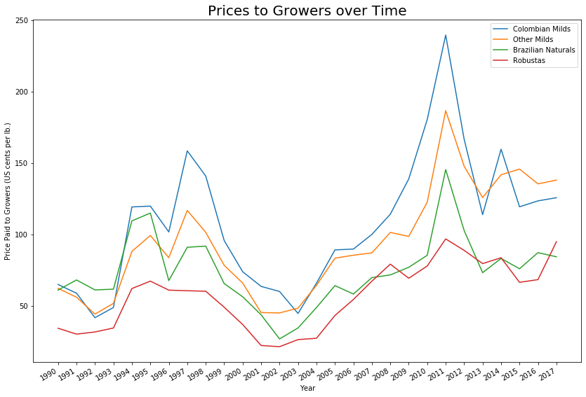

```python
# group by producer group and year and find median countries
price_by_group = prices_to_growers.groupby(by=['group', 'year']).median()

fig, ax = plt.subplots()
fig.set_size_inches(14, 10)
fig.autofmt_xdate()

for group in groups:
    x = price_by_group['price'][group].index
    y = price_by_group['price'][group]
    line, = ax.plot(x, y)
    line.set_label(group)

ax.set_title('Prices to Growers over Time', fontsize=20)
ax.set_xlabel('Year')
ax.set_ylabel('Price Paid to Growers (US cents per lb.)')
ax.legend()

plt.show()
```

We see similar trends over time in prices paid to growers as in market price. What about differences in prices paid to growers within each category of coffee? Let's construct boxplots for prices paid to growers grouped by type of coffee. We'll hide outliers to make the plot more readable.

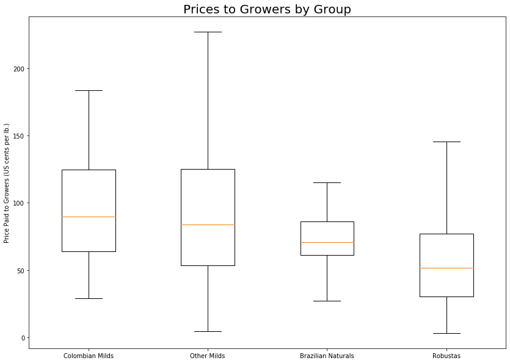

```python
fig, ax = plt.subplots()
fig.set_size_inches(14, 10)

# list comprehension to separate prices by producer group
x = [prices_to_growers[prices_to_growers['group'] == group]['price'] for group in groups]
ax.boxplot(x, labels=groups, showfliers=False)

ax.set_title('Prices to Growers by Group', fontsize=20)
ax.set_ylabel('Price Paid to Growers (US cents per lb.)')

plt.show()
```

From the boxplots, we see that countries producing primarily Colombian Milds or Other Milds have similar prices paid to growers, with the main difference being that Other Milds has a much larger spread. Countries producing primarily Robusta have signficantly lower prices paid to growers, likely as a function of the lower market prices of Robusta coffee.

We can't gain significant insight into the coffee market from price data alone. Combined with production data, however, we can begin to see what factors drives the coffee prices that growers face.

### Production Data

The ICO collects data on coffee production from its member countries. Specifically, we'll look at the Domestic Consumption and Exportable Production datasets. These represent the amount of coffee consumed domestically by producing countries and the amount of coffee available for export, repsectively. Together, they add up to the total production of a producing country for a given year. All units represent thousands of 60kg bags of green coffee.

Both datasets have the same format, so we can use the same cleaning procedure on both.

```python
url = 'http://www.ico.org/historical/1990%20onwards/Excel/1b%20-%20Domestic%20consumption.xlsx'
df = pd.read_excel(url, header=3, skipfooter=1).dropna(how='all')

df.head()
```

|  | Crop year | Unnamed: 1 | 1990/91 | 1991/92 | 1992/93 | 1993/94 | 1994/95 | 1995/96 | 1996/97 | 1997/98 | ... | 2009/10 | 2010/11 | 2011/12 | 2012/13 | 2013/14 | 2014/15 | 2015/16 | 2016/17 | 2017/18 | 2018/19 |
| --- | --- | --- | --- | --- | --- | --- | --- | --- | --- | --- | --- | --- | --- | --- | --- | --- | --- | --- | --- | --- | --- |
| 1 | April group | NaN | 10408.0 | 10710.6 | 11214.7 | 11459.243 | 11511.999 | 12343.6 | 13244.0 | 13817.0 | ... | 22709.399 | 23451.92 | 24356.726 | 25180.201 | 25187.529 | 25581.414 | 25903.29 | 26710.49 | 27572.49 | 27572.49 |
| 2 | Angola | (R/A) | 20.0 | 30.0 | 35.0 | 20.000 | 25.000 | 10.0 | 20.0 | 40.0 | ... | 30.000 | 30.00 | 30.000 | 30.000 | 30.000 | 30.000 | 30.00 | 30.00 | 30.00 | 30.00 |
| 3 | Bolivia | (A) | 25.0 | 30.0 | 30.0 | 35.000 | 35.000 | 40.0 | 40.0 | 45.0 | ... | 60.000 | 60.00 | 60.000 | 60.000 | 60.000 | 60.000 | 60.00 | 60.00 | 60.00 | 60.00 |
| 4 | Brazil | (A/R) | 8200.0 | 8500.0 | 8900.0 | 9100.000 | 9300.000 | 10100.0 | 11000.0 | 11500.0 | ... | 18390.000 | 19132.00 | 19720.000 | 20330.000 | 20085.000 | 20333.000 | 20508.00 | 21225.00 | 21997.00 | 21997.00 |
| 5 | Burundi | (A) | 2.0 | 1.6 | 1.7 | 1.910 | 2.000 | 2.0 | 2.0 | 2.0 | ... | 1.399 | 2.00 | 2.000 | 2.000 | 2.000 | 2.000 | 2.00 | 2.00 | 2.00 | 2.00 |

5 rows × 31 columns

We want to transform the data so that every row represents an observation of the quantity produced by a country for a given year. Unlike the prices to growers dataset, each column contains a year range rather than a single year. This is due to how the harvest and growing cycle aligns with the calendar year. Note that different countries also harvest at different times of the year (and some more than once! - Counter Culture Coffee has a great interactive map to see when harvests occur in each county: https://counterculturecoffee.com/learn/resource-center/coffee-seasonality). We'll also want to remove all of the rows that are group-level aggregates.

```python
def read_production_ico(df):
    series = []
    for index, row in df.iterrows():
        # ignore rows that are aggregates
        if 'group' not in row['Crop year'] and row['Crop year'] != 'Total':
            base = 1990
            years = 2018 - base
            for i in range(years):
                obs = {}
                obs['country'] = row['Crop year']
                obs['quantity'] = row[i + 2]
                obs['year'] = str(base + i)
                series.append(obs)
    return pd.DataFrame(series).dropna(how='any')
```

Nice! Now let's read in the domestic consumption dataset:

```python
domestic_consumption = read_production_ico(df)

domestic_consumption.head()
```

|  | country | quantity | year |
| --- | --- | --- | --- |
| 0 | Angola | 20.0 | 1990 |
| 1 | Angola | 30.0 | 1991 |
| 2 | Angola | 35.0 | 1992 |
| 3 | Angola | 20.0 | 1993 |
| 4 | Angola | 25.0 | 1994 |

And do the same for exportable production:

```python
url = 'http://www.ico.org/historical/1990%20onwards/Excel/1c%20-%20Exportable%20production.xlsx'
df = pd.read_excel(url, header=3, skipfooter=1).dropna(how='all')

exportable_production = read_production_ico(df)
exportable_production.head()
```

|  | country | quantity | year |
| --- | --- | --- | --- |
| 0 | Angola | 30.345 | 1990 |
| 1 | Angola | 49.331 | 1991 |
| 2 | Angola | 42.520 | 1992 |
| 3 | Angola | 12.608 | 1993 |
| 4 | Angola | 51.802 | 1994 |

Let's join them and add a new column for total production (the sum of the `quantity` columns from both dataframes.

```python
# rename quantity columns
exportable_production = exportable_production.rename(columns={'quantity': 'exportable_production'})
domestic_consumption = domestic_consumption.rename(columns={'quantity': 'domestic_consumption'})

# merge dataframes
production = pd.merge(domestic_consumption, exportable_production,
                      how='inner', left_on=['year', 'country'], right_on=['year', 'country'])

# create quantity column
production['total'] = production['domestic_consumption'] + production['exportable_production']

production.head()
```

|  | country | domestic_consumption | year | exportable_production | total |
| --- | --- | --- | --- | --- | --- |
| 0 | Angola | 20.0 | 1990 | 30.345 | 50.345 |
| 1 | Angola | 30.0 | 1991 | 49.331 | 79.331 |
| 2 | Angola | 35.0 | 1992 | 42.520 | 77.520 |
| 3 | Angola | 20.0 | 1993 | 12.608 | 32.608 |
| 4 | Angola | 25.0 | 1994 | 51.802 | 76.802 |

How has total coffee production changed over time?

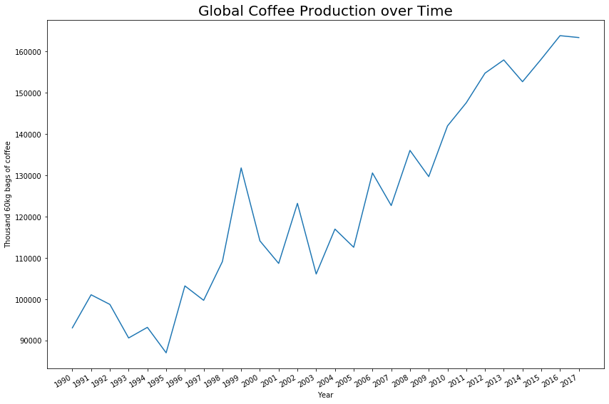

```python
# total production for each year
production_by_year = production.groupby('year').sum()['total']

fig, ax = plt.subplots()
fig.set_size_inches(14, 10)
fig.autofmt_xdate()

x = production_by_year.index
y = production_by_year
line, = ax.plot(x, y)

ax.set_title('Global Coffee Production over Time', fontsize=20)
ax.set_xlabel('Year')
ax.set_ylabel('Thousand 60kg bags of coffee')

plt.show()
```

At this point, we have the `indicator_prices`, `prices_to_growers`, and `production` datasets. Now, let's use `indicator_prices` and `production` to estimate prices to growers.

## Analysis

### Estimation Strategy

Our goal is to predict prices to growers as a function of market prices and production-related variables for a given country. We'll do this using (1) linear regression and (2) random forests. The general relationship for this model will be:

$$PricetoGrowers = ProducerGroup + MarketPrice + DomesticRatio$$

Where `ProducerGroup` is the primary group of coffee that a country produces, `MarketPrice` is the market price for the primary kind of coffee that a country produces, and `DomesticRatio` is the ratio of domestic consumption to total production of a country. For linear regression, we will have to transform each of the producer groups into a separate binary variable, and market price into an interaction term between each binary producer group variable and its associated market price. The fully specified linear regression equation will have the form:

$$PricetoGrowers = β_1*IsColombianMild + β_2*IsOtherMild + β_3*IsBrazilianNatural + β_4*IsRobusta + β_5*IsColombianMild*ColombianMild + β_6*IsOtherMild*OtherMild B_7*IsBrazilianNatural*BrazilianNatural + β_8*IsRobusta*Robusta + β_9*DomesticRatio$$

Note that we don't include a constant term, as it would create a collinear relationship between the binary variables for producer group. Let's transform the data so we can run the regression.

### Data Preparation

```python
# merge prices_to grower, production, and indicator prices
left = pd.merge(prices_to_growers, production,
               how='inner', left_on=['country','year'], right_on = ['country','year'])
# average indicator prices by year
right = indicator_prices.groupby('year').mean().drop(columns='date')
data = pd.merge(left, right, how='left', left_on=['year'], right_index=True)

# calculate ratio of domestic consumption to total production
data['domestic_ratio'] = data['domestic_consumption'] / data['total']

data.head()
```

|  | year | country | price | group | domestic_consumption | exportable_production | total | composite | colombian_milds | other_milds | brazilian_naturals | robustas | domestic_ratio |
| --- | --- | --- | --- | --- | --- | --- | --- | --- | --- | --- | --- | --- | --- |
| 0 | 1990 | Colombia | 69.5230 | Colombian Milds | 1235.0 | 13033.387 | 14268.387 | 71.532500 | 96.533333 | 89.456667 | 82.968333 | 53.602500 | 0.086555 |
| 1 | 1991 | Colombia | 67.1251 | Colombian Milds | 1400.0 | 16414.866 | 17814.866 | 66.800833 | 89.762500 | 84.975833 | 72.911667 | 48.620833 | 0.078586 |
| 2 | 1992 | Colombia | 54.5709 | Colombian Milds | 1300.0 | 13889.131 | 15189.131 | 53.351667 | 67.965000 | 64.044167 | 56.486667 | 42.657500 | 0.085588 |
| 3 | 1993 | Colombia | 50.1234 | Colombian Milds | 1400.0 | 8897.602 | 10297.602 | 61.630833 | 75.787500 | 70.761667 | 66.575000 | 52.496667 | 0.135954 |
| 4 | 1994 | Colombia | 85.9942 | Colombian Milds | 1375.0 | 11487.470 | 12862.470 | 134.452500 | 157.270833 | 150.037500 | 143.242500 | 118.865000 | 0.106900 |

First, we merge all of the datsets together. We transform indicator prices by taking the average price over a year, and drop the date column (since we only need the year). Then, we create a new column for the `domestic_ratio` variable. Let's convert `group` to four separate binary variables and add interaction terms with price.

```python
from sklearn.feature_extraction import DictVectorizer

# create dict from group column, extract features
subset = data[['group']].to_dict('records')
vec = DictVectorizer()
features = vec.fit_transform(subset).toarray()

# create new df, merge with existing
cols = ['is_brazilian_natural', 'is_colombian_mild', 'is_other_mild', 'is_robusta']
features_matrix = pd.DataFrame(features, columns=cols)
data = data.join(features_matrix)

# add interaction terms
data['int_colombian_milds'] = data['colombian_milds'] * data['is_colombian_mild']
data['int_other_milds'] = data['other_milds'] * data['is_other_mild']
data['int_brazilian_naturals'] = data['brazilian_naturals'] * data['is_brazilian_natural']
data['int_robustas'] = data['robustas'] * data['is_robusta']

data = data.dropna(how='any')
data.head()
```

|  | year | country | price | group | domestic_consumption | exportable_production | total | composite | colombian_milds | other_milds | ... | robustas | domestic_ratio | is_brazilian_natural | is_colombian_mild | is_other_mild | is_robusta | int_colombian_milds | int_other_milds | int_brazilian_naturals | int_robustas |
| --- | --- | --- | --- | --- | --- | --- | --- | --- | --- | --- | --- | --- | --- | --- | --- | --- | --- | --- | --- | --- | --- |
| 0 | 1990 | Colombia | 69.5230 | Colombian Milds | 1235.0 | 13033.387 | 14268.387 | 71.532500 | 96.533333 | 89.456667 | ... | 53.602500 | 0.086555 | 0.0 | 1.0 | 0.0 | 0.0 | 96.533333 | 0.0 | 0.0 | 0.0 |
| 1 | 1991 | Colombia | 67.1251 | Colombian Milds | 1400.0 | 16414.866 | 17814.866 | 66.800833 | 89.762500 | 84.975833 | ... | 48.620833 | 0.078586 | 0.0 | 1.0 | 0.0 | 0.0 | 89.762500 | 0.0 | 0.0 | 0.0 |
| 2 | 1992 | Colombia | 54.5709 | Colombian Milds | 1300.0 | 13889.131 | 15189.131 | 53.351667 | 67.965000 | 64.044167 | ... | 42.657500 | 0.085588 | 0.0 | 1.0 | 0.0 | 0.0 | 67.965000 | 0.0 | 0.0 | 0.0 |
| 3 | 1993 | Colombia | 50.1234 | Colombian Milds | 1400.0 | 8897.602 | 10297.602 | 61.630833 | 75.787500 | 70.761667 | ... | 52.496667 | 0.135954 | 0.0 | 1.0 | 0.0 | 0.0 | 75.787500 | 0.0 | 0.0 | 0.0 |
| 4 | 1994 | Colombia | 85.9942 | Colombian Milds | 1375.0 | 11487.470 | 12862.470 | 134.452500 | 157.270833 | 150.037500 | ... | 118.865000 | 0.106900 | 0.0 | 1.0 | 0.0 | 0.0 | 157.270833 | 0.0 | 0.0 | 0.0 |

5 rows × 21 columns

`sklearn` is a powerful machine learning library that pre-packaged version of many machine learning algorithms. For now, we just use the feature extraction module to transform our categorical variables (see https://scikit-learn.org/stable/modules/feature_extraction.html for a full overview of its feature extraction functionality).

### Linear Regression

Now we can run our previously specified regression. To run the regression, we'll use `statsmodels`, as it has more detailed output than `sklearn`'s OLS implementation.

```python
import statsmodels.api as sm

X = data[['is_colombian_mild', 'is_other_mild', 'is_brazilian_natural', 'is_robusta',
          'int_colombian_milds', 'int_other_milds', 'int_brazilian_naturals', 'int_robustas',
          'domestic_ratio']]
y = data[['price']]

mod = sm.OLS(y, X)
ols_res = mod.fit()
ols_res.summary()
```

OLS Regression Results

| Dep. Variable: | price | R-squared: | 0.390 |
| --- | --- | --- | --- |
| Model: | OLS | Adj. R-squared: | 0.385 |
| Method: | Least Squares | F-statistic: | 89.09 |
| Date: | Sun, 15 Dec 2019 | Prob (F-statistic): | 3.59e-114 |
| Time: | 18:15:43 | Log-Likelihood: | -5779.7 |
| No. Observations: | 1125 | AIC: | 1.158e+04 |
| Df Residuals: | 1116 | BIC: | 1.162e+04 |
| Df Model: | 8 |  |  |
| Covariance Type: | nonrobust |  |  |

|  | coef | std err | t | P>\|t\| | [0.025 | 0.975] |
| --- | --- | --- | --- | --- | --- | --- |
| is_colombian_mild | -10.3260 | 17.063 | -0.605 | 0.545 | -43.806 | 23.154 |
| is_other_mild | 19.7603 | 6.191 | 3.192 | 0.001 | 7.612 | 31.908 |
| is_brazilian_natural | 2.0954 | 21.252 | 0.099 | 0.921 | -39.603 | 43.794 |
| is_robusta | 1.3742 | 4.351 | 0.316 | 0.752 | -7.164 | 9.912 |
| int_colombian_milds | 0.8443 | 0.125 | 6.737 | 0.000 | 0.598 | 1.090 |
| int_other_milds | 0.5945 | 0.047 | 12.730 | 0.000 | 0.503 | 0.686 |
| int_brazilian_naturals | 0.4885 | 0.172 | 2.837 | 0.005 | 0.151 | 0.826 |
| int_robustas | 0.6562 | 0.054 | 12.115 | 0.000 | 0.550 | 0.762 |
| domestic_ratio | 31.5455 | 4.233 | 7.452 | 0.000 | 23.239 | 39.852 |

| Omnibus: | 584.646 | Durbin-Watson: | 0.683 |
| --- | --- | --- | --- |
| Prob(Omnibus): | 0.000 | Jarque-Bera (JB): | 5841.110 |
| Skew: | 2.183 | Prob(JB): | 0.00 |
| Kurtosis: | 13.274 | Cond. No. | 1.24e+03 |

Warnings:  
[1] Standard Errors assume that the covariance matrix of the errors is correctly specified.  
[2] The condition number is large, 1.24e+03. This might indicate that there are  
strong multicollinearity or other numerical problems.

From the output, we see that our model obtained a moderate R<sup>2</sup> of .39. All of the coefficients on the independent variables were statistically significant with the expection of the binary variables for colombian milds, brazilian naturals, and robustas. Let's visualize the results of the model.

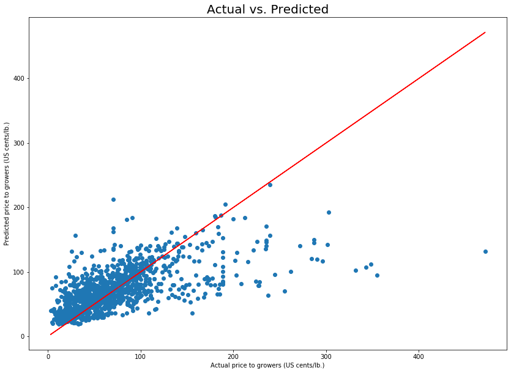

```python
fig, ax = plt.subplots()
fig.set_size_inches(14, 10)

ax.scatter(y, ols_res.predict(X))
ax.plot(y, y, color='red')

ax.set_title('Actual vs. Predicted', fontsize=20)
ax.set_xlabel('Actual price to growers (US cents/lb.)')
ax.set_ylabel('Predicted price to growers (US cents/lb.)')

plt.show()
```

From the graph comparing actual and predicted prices to growers, it seems that the model tends to underestimate the price to growers at higher prices. This could be due to the fact that there were significantly less data with very high prices to growers. Another strategy we can use to understand the model is to plot the residuals (the difference between actual and predicted values) vs. an independent variable. As an example, let's plot residuals against the ratio of dometic consumption to total production.

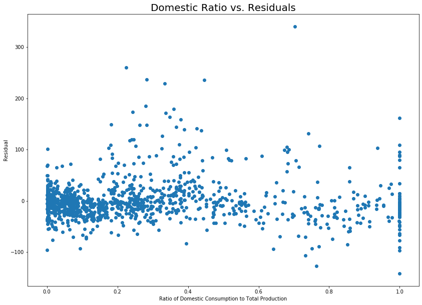

```python
residuals = y['price'] - ols_res.predict(X)

fig, ax = plt.subplots()
fig.set_size_inches(14, 10)

ax.scatter(data['domestic_ratio'], residuals)

ax.set_title('Domestic Ratio vs. Residuals', fontsize=20)
ax.set_xlabel('Ratio of Domestic Consumption to Total Production')
ax.set_ylabel('Residual')

plt.show()
```

From the residual plot, we see that there is no clear relation between the prediction error and domestic ratio, which is what would be expected of a correctly specified regression equation. There does seem to be a large amount of prediction error for countries who consume all of the coffee that they produce. This seems expected, given that these countries make up a relatively small portion of the sample.

Given that there was some collinearity among the independent variables, let's also compare the performance of a decision tree based method.

### Random Forests

Random forests is a machine learning method based on decision trees. Rather than creating a single tree, it creates many trees (in our case, 1000) and averages their predictions. For a more comprehensive overview, see the Wikipedia entry: https://en.wikipedia.org/wiki/Random_forest.

```python
from sklearn.ensemble import RandomForestRegressor

rf = RandomForestRegressor(n_estimators=1000, random_state=0, max_depth=5)
rf.fit(X, y['price'])
rf.score(X, y['price'])
```

```
0.5685290219577861
```

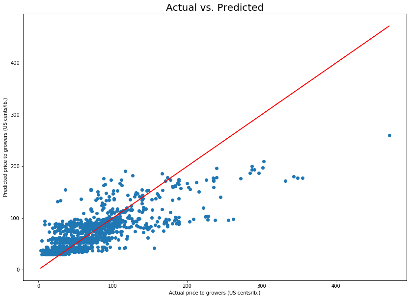

```python
fig, ax = plt.subplots()
fig.set_size_inches(14, 10)

ax.scatter(y, rf.predict(X))
ax.plot(y, y, color='red')

ax.set_title('Actual vs. Predicted', fontsize=20)
ax.set_xlabel('Actual price to growers (US cents/lb.)')
ax.set_ylabel('Predicted price to growers (US cents/lb.)')

plt.show()
```

As a result of limiting the depth of the trees, we see some grouping in the predicted data. However, leaving the depth unrestricted could lead to overfiting of the data.

Random forests also gives us another metric to consider: variable importance (a measure of how much accuracy decreases when the variable is removed).

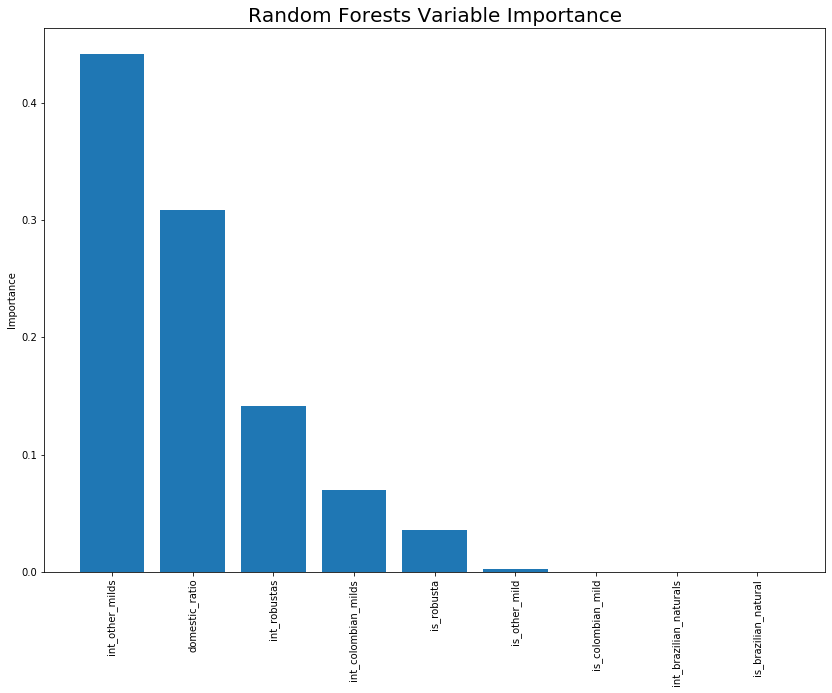

```python
importances = pd.DataFrame()
importances['value'] = rf.feature_importances_
importances['name'] = X.columns
importances = importances.sort_values(by='value', ascending=False).reset_index()

fig, ax = plt.subplots()
fig.set_size_inches(14, 10)

ax.bar(importances.index, importances['value'])

ax.set_title('Random Forests Variable Importance', fontsize=20)
ax.set_ylabel('Importance')

plt.xticks(importances.index, importances['name'], rotation=90)
plt.show()
```

From the variable importance plot, we see that the ratio of domestic consumption to total productiona and the interaction terms between market price and producer group are the most important variables in predicting prices to growers.

## Final Thoughts

Clearly, there are many complex factors affecting the farmgate price paid to coffee growers, many of which are not contained in the data collected by the ICO. While it's intuitive that the market price of coffee should affect the amount that growers are paid, the importance of the ratio of domestic consumption to production is not as clear. It's possible that countries that consume more of the coffee they produce share commonalities in terms of wage structure and worker compensation. Or, growers may be able to sell directly to in-country coffee roasters rather than working with large, multinational coffee exporters that need to guarantee a profit.